# Under-5 Mortality: A Global Perspective

Author

Padmaja Huprikar(A00010704)

# 🌍 Introduction

Child mortality remains one of the most pressing global challenges. This report explores trends and disparities in under-5 mortality across countries, continents, and genders using UNICEF data. Visualizations are created using Python with Polars and Plotnine.

# 📊 Chart 1: Global Average Mortality Trend Over Time

This chart tracks the global average under-5 mortality rate across years, highlighting an overall declining trend and reflecting progress in healthcare access and maternal support.

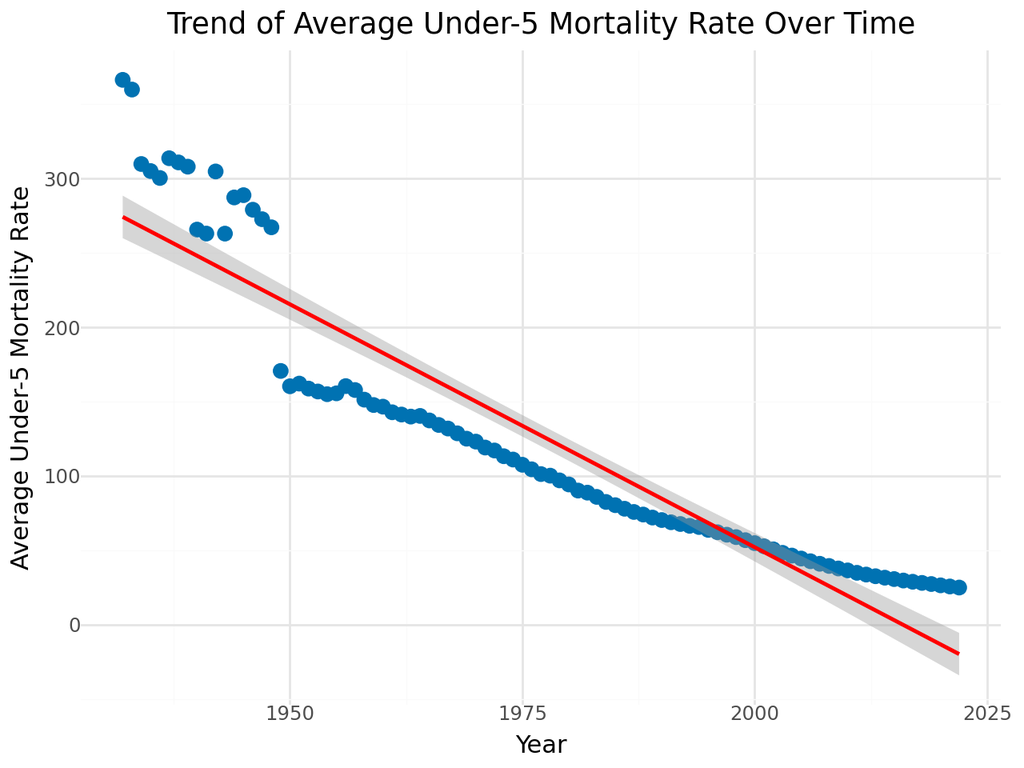

```python
import polars as pl
from plotnine import ggplot, aes, geom_point, geom_smooth, labs, theme_minimal

# Load and prepare data in Polars
df = pl.read_csv("unicef_indicator_1.csv")
df = df.rename({col: col.strip() for col in df.columns})
df = df.filter(pl.col("indicator").str.to_lowercase().str.contains("mortality"))
df = df.drop_nulls(subset=["obs_value", "time_period", "country"])

# Group by year and calculate average mortality
avg_df = df.group_by("time_period").agg(
    pl.col("obs_value").mean().alias("avg_mortality")
).sort("time_period")

# Convert to pandas for plotnine
avg_df_pd = avg_df.to_pandas()
avg_df_pd["time_period"] = avg_df_pd["time_period"].astype(int)

# Plot with regression line
from plotnine import ggplot, aes, geom_point, geom_smooth, labs, theme_minimal

plot = (
    ggplot(avg_df_pd, aes(x="time_period", y="avg_mortality"))
    + geom_point(color="#0072B2", size=3)
    + geom_smooth(method="lm", se=True, color="red")
    + labs(
        title="Trend of Average Under-5 Mortality Rate Over Time",
        x="Year",
        y="Average Under-5 Mortality Rate"
    )
    + theme_minimal()
)

plot
```

This choropleth map visualizes country-level under-5 mortality for the most recent year available. Darker shades indicate higher mortality rates, highlighting regions with urgent healthcare needs.

```
UserWarning: Glyph 127757 (\N{EARTH GLOBE EUROPE-AFRICA}) missing from font(s) DejaVu Sans.
```

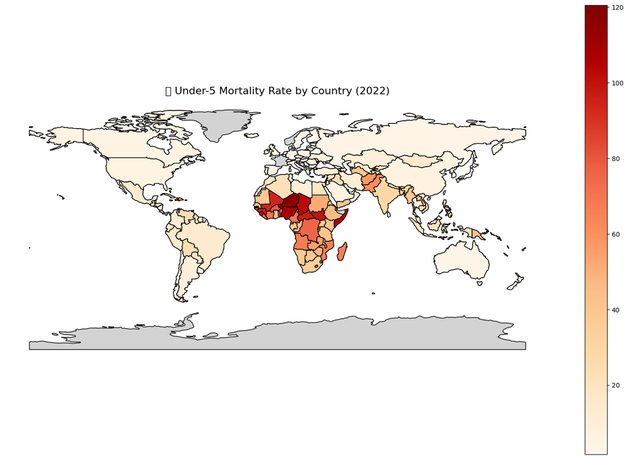

```python
import pandas as pd
import matplotlib.pyplot as plt

# Load UNICEF data
df = pd.read_csv("unicef_indicator_1.csv")

# Clean column names
df.columns = df.columns.str.strip()

# Filter for Under-5 mortality only
mortality_df = df[df["indicator"].str.contains("mortality", case=False)]

# Use most recent year (2022) if available
latest_year = mortality_df["time_period"].max()

# Filter for latest year
mortality_2022 = mortality_df[mortality_df["time_period"] == latest_year]

# Keep only relevant columns
mortality_2022 = mortality_2022[["alpha_3_code", "obs_value", "country"]].rename(
    columns={
        "alpha_3_code": "iso_a3",
        "obs_value": "under5_mortality",
        "country": "country_name"
    }
)

# Merge with shapefile GeoDataFrame
world_merged = world.merge(mortality_2022, how="left", left_on="ISO_A3", right_on="iso_a3")

# Plot
fig, ax = plt.subplots(1, 1, figsize=(15, 10))
world_merged.plot(
    column="under5_mortality",
    ax=ax,
    legend=True,
    cmap="OrRd",
    edgecolor="black",
    missing_kwds={
        "color": "lightgrey",
        "label": "No data"
    }
)

ax.set_title(f"🌍 Under-5 Mortality Rate by Country ({latest_year})", fontsize=16)
ax.axis("off")

plt.tight_layout()
plt.show()
```

[figure not shown]

```python
# Convert to pandas for ranking
df_pd = df.to_pandas()
df_pd["time_period"] = df_pd["time_period"].astype(int)

# Get the latest year (e.g. 2022)
latest_year = df_pd["time_period"].max()

# Filter for latest year & get top 15 by mortality
top15 = (
    df_pd[df_pd["time_period"] == latest_year]
    .sort_values("obs_value", ascending=False)
    .head(15)
)

# Bar chart
from plotnine import ggplot, aes, geom_col, coord_flip, labs, theme_minimal

chart1 = (
    ggplot(top15, aes(x="country", y="obs_value"))
    + geom_col(fill="#d73027")
    + coord_flip()
    + labs(
        title=f"Top 15 Countries by Under-5 Mortality Rate ({latest_year})",
        x="Country",
        y="Mortality Rate"
    )
    + theme_minimal()
)
chart1
```

Mortality rates are broken down by sex. In comparison to females, the mortality rate of male children is high.

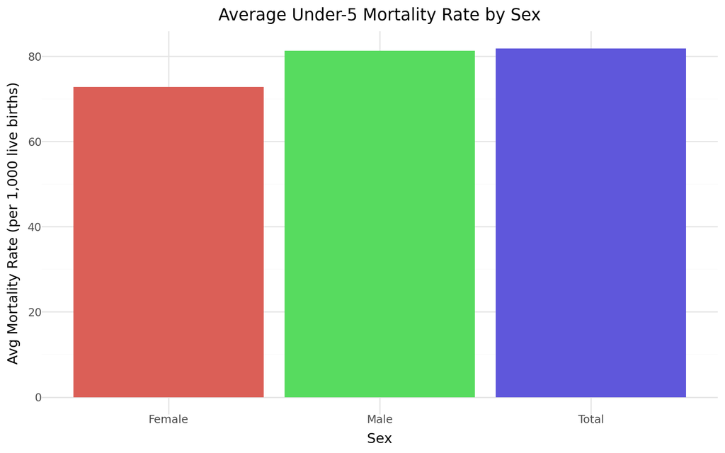

```python
# Install packages if needed (only once)
!pip install plotnine polars

# Import necessary libraries
import polars as pl
from plotnine import *

# Load and clean dataset
df = pl.read_csv("unicef_indicator_1.csv")
df = df.rename({col: col.strip() for col in df.columns})
df = df.filter(pl.col("indicator").str.to_lowercase().str.contains("mortality"))
df = df.drop_nulls(subset=["obs_value", "sex"])  # Ensure 'sex' column exists

# Group by sex and calculate average mortality
df_sex = df.group_by("sex").agg(
    pl.col("obs_value").mean().alias("avg_mortality")
).sort("sex")

# Convert to pandas for plotnine
df_sex_pd = df_sex.to_pandas()

# Plot bar chart
fig = (
    ggplot(df_sex_pd, aes(x="sex", y="avg_mortality", fill="sex")) +
    geom_bar(stat="identity", show_legend=False) +
    labs(
        title="Average Under-5 Mortality Rate by Sex",
        x="Sex",
        y="Avg Mortality Rate (per 1,000 live births)"
    ) +
    theme_minimal() +
    theme(
        figure_size=(8, 5)
    )
)

fig
```

This scatter plot shows per-country mortality across time, color-coded by continent. Regression lines capture overall trends, showing steady improvement globally — though some continents lag behind.

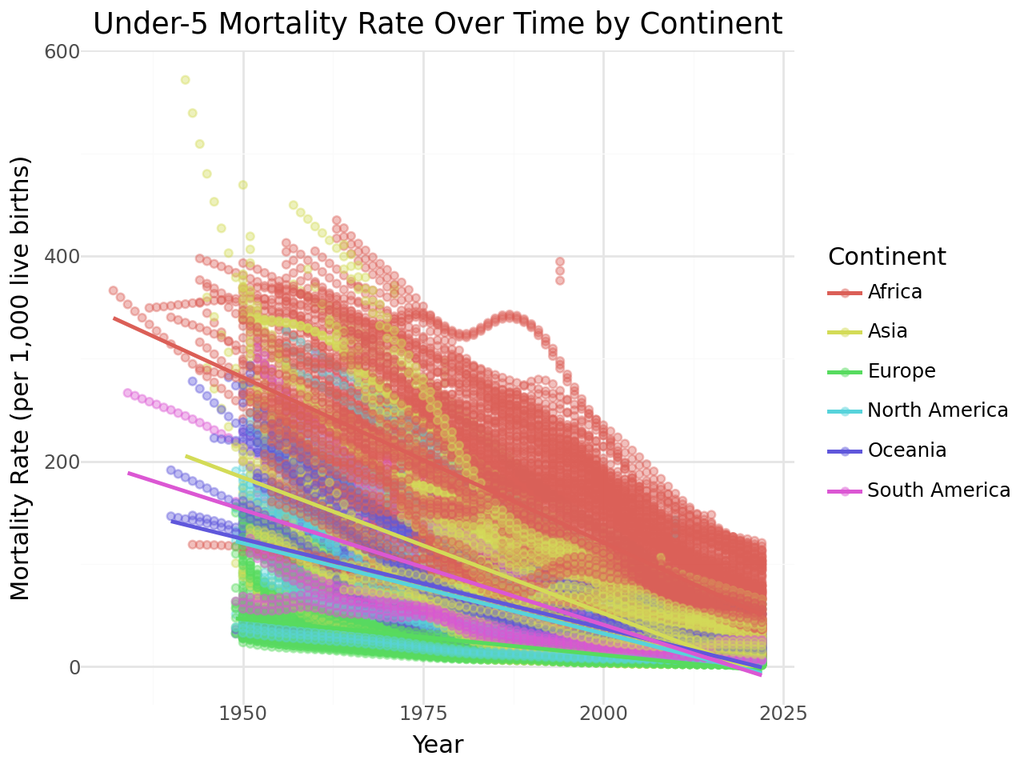

```python
import polars as pl
import pandas as pd
import pycountry
import pycountry_convert as pc
from plotnine import *

# Load data
df = pl.read_csv("unicef_indicator_1.csv")
df = df.rename({col: col.strip() for col in df.columns})
df = df.filter(pl.col("indicator").str.to_lowercase().str.contains("mortality"))
df = df.drop_nulls(subset=["obs_value", "time_period", "country"])

# === Map country to continent ===
def get_continent(country_name):
    try:
        country = pycountry.countries.get(name=country_name)
        if not country:
            country = pycountry.countries.search_fuzzy(country_name)[0]
        alpha2 = country.alpha_2
        cont_code = pc.country_alpha2_to_continent_code(alpha2)
        return pc.convert_continent_code_to_continent_name(cont_code)
    except:
        return None

unique_countries = df.select("country").unique().to_series().to_list()
continent_df = pl.DataFrame({
    "country": unique_countries,
    "continent": [get_continent(c) for c in unique_countries]
}).drop_nulls()

# Join continent info
df_continent = df.join(continent_df, on="country", how="left").drop_nulls(subset=["continent"])

# Convert to pandas for plotnine
df_scatter = df_continent.to_pandas()
df_scatter["time_period"] = df_scatter["time_period"].astype(int)

# === Scatterplot with regression line per continent ===
scatter_continent = (
    ggplot(df_scatter, aes(x="time_period", y="obs_value", color="continent")) +
    geom_point(alpha=0.4, size=1.5) +
    geom_smooth(method="lm", se=False) +
    labs(
        title="Under-5 Mortality Rate Over Time by Continent",
        x="Year",
        y="Mortality Rate (per 1,000 live births)",
        color="Continent"
    ) +
    theme_minimal()
)

scatter_continent
```

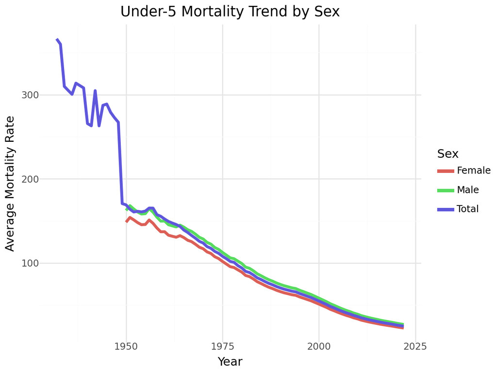

```python
# Group by time_period and sex
trend_sex = (
    df.group_by(["time_period", "sex"])
    .agg(pl.col("obs_value").mean().alias("avg_mortality"))
    .sort(["sex", "time_period"])
    .to_pandas()
)

trend_sex["time_period"] = trend_sex["time_period"].astype(int)

from plotnine import ggplot, aes, geom_line, labs, theme_minimal

chart2 = (
    ggplot(trend_sex, aes(x="time_period", y="avg_mortality", color="sex"))
    + geom_line(size=1.5)
    + labs(
        title="Under-5 Mortality Trend by Sex",
        x="Year",
        y="Average Mortality Rate",
        color="Sex"
    )
    + theme_minimal()
)
chart2
```

[output not shown]

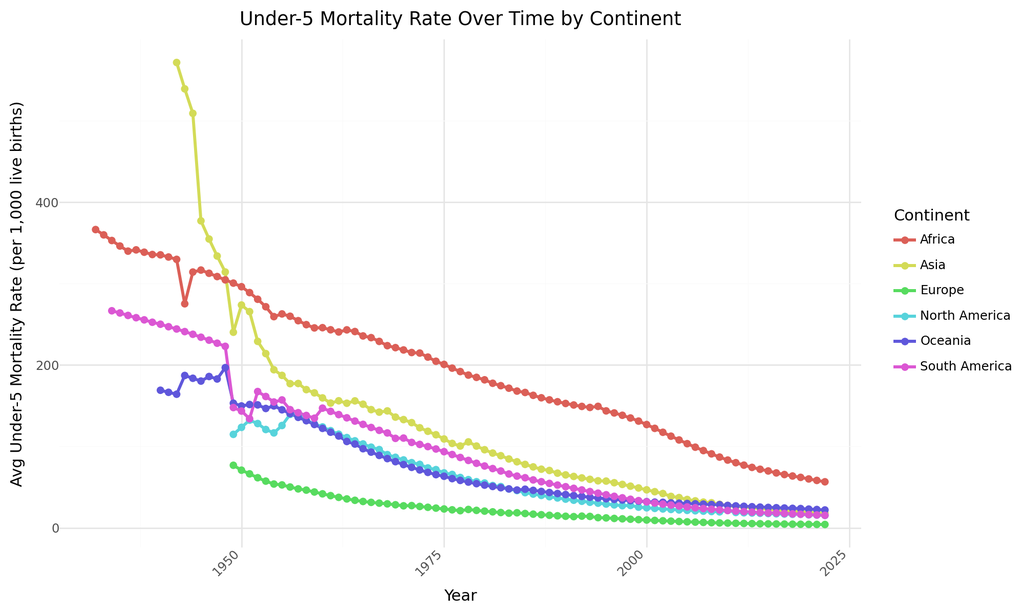

```python
# Step 1: Install required packages (if not already)
!pip install pycountry pycountry-convert plotnine polars

# Step 2: Import libraries
import polars as pl
import pycountry
import pycountry_convert as pc
from plotnine import *

# Step 3: Load the dataset (check the exact name you uploaded!)
df = pl.read_csv("unicef_indicator_1.csv")  # ✅ correct file name

# Step 4: Clean and filter
df = df.rename({col: col.strip() for col in df.columns})
df = df.filter(pl.col("indicator").str.to_lowercase().str.contains("mortality"))
df = df.drop_nulls(subset=["obs_value", "time_period", "country"])

# Step 5: Map countries to continents
def get_continent(country_name):
    try:
        country = pycountry.countries.get(name=country_name)
        if not country:
            country = pycountry.countries.search_fuzzy(country_name)[0]
        alpha2 = country.alpha_2
        continent_code = pc.country_alpha2_to_continent_code(alpha2)
        return pc.convert_continent_code_to_continent_name(continent_code)
    except:
        return None

# Create continent map
unique_countries = df.select("country").unique().to_series().to_list()
continent_df = pl.DataFrame({
    "country": unique_countries,
    "continent": [get_continent(c) for c in unique_countries]
}).drop_nulls()

# Merge into main dataset
df_with_continent = df.join(continent_df, on="country", how="left").drop_nulls(subset=["continent"])

# Step 6: Aggregate mortality rates by continent and year
df_continent_trend = df_with_continent.group_by(["continent", "time_period"]).agg(
    pl.col("obs_value").mean().alias("avg_mortality")
).sort(["continent", "time_period"])

# Step 7: Convert to pandas for plotnine
df_continent_trend_pd = df_continent_trend.to_pandas()

# Step 8: Plot using plotnine
fig = (
    ggplot(df_continent_trend_pd, aes(x="time_period", y="avg_mortality", color="continent")) +
    geom_line(size=1.2) +
    geom_point(size=2) +
    labs(
        title="Under-5 Mortality Rate Over Time by Continent",
        x="Year",
        y="Avg Under-5 Mortality Rate (per 1,000 live births)",
        color="Continent"
    ) +
    theme_minimal() +
    theme(
        figure_size=(10, 6),
        axis_text_x=element_text(rotation=45, ha='right')
    )
)

fig
```

```python
import zipfile
import os

# Set correct file paths
zip_path = "ne_countries.zip"  # Update if named differently
unzip_dir = "world_shapes/unzipped"
os.makedirs(unzip_dir, exist_ok=True)

# Unzip it
with zipfile.ZipFile(zip_path, 'r') as zip_ref:
    zip_ref.extractall(unzip_dir)

# Check contents
print("✅ Extracted contents:")
print(os.listdir(unzip_dir))
```

```
✅ Extracted contents:
['ne_countries']
```

```python
os.listdir("world_shapes/unzipped/ne_countries")
```

```
['ne_110m_admin_0_countries.dbf',
 'ne_110m_admin_0_countries.shp',
 'ne_110m_admin_0_countries.shx',
 'ne_110m_admin_0_countries.prj']
```

```python
import geopandas as gpd

# Load the shapefile
world = gpd.read_file("world_shapes/unzipped/ne_countries/ne_110m_admin_0_countries.shp")
world.head()
```

|  | featurecla | scalerank | LABELRANK | SOVEREIGNT | SOV_A3 | ADM0_DIF | LEVEL | TYPE | TLC | ADMIN | ... | FCLASS_TR | FCLASS_ID | FCLASS_PL | FCLASS_GR | FCLASS_IT | FCLASS_NL | FCLASS_SE | FCLASS_BD | FCLASS_UA | geometry |
| --- | --- | --- | --- | --- | --- | --- | --- | --- | --- | --- | --- | --- | --- | --- | --- | --- | --- | --- | --- | --- | --- |
| 0 | Admin-0 country | 1 | 6 | Fiji | FJI | 0 | 2 | Sovereign country | 1 | Fiji | ... | None | None | None | None | None | None | None | None | None | MULTIPOLYGON (((180 -16.06713, 180 -16.55522, ... |
| 1 | Admin-0 country | 1 | 3 | United Republic of Tanzania | TZA | 0 | 2 | Sovereign country | 1 | United Republic of Tanzania | ... | None | None | None | None | None | None | None | None | None | POLYGON ((33.90371 -0.95, 34.07262 -1.05982, 3... |
| 2 | Admin-0 country | 1 | 7 | Western Sahara | SAH | 0 | 2 | Indeterminate | 1 | Western Sahara | ... | Unrecognized | Unrecognized | Unrecognized | None | None | Unrecognized | None | None | None | POLYGON ((-8.66559 27.65643, -8.66512 27.58948... |
| 3 | Admin-0 country | 1 | 2 | Canada | CAN | 0 | 2 | Sovereign country | 1 | Canada | ... | None | None | None | None | None | None | None | None | None | MULTIPOLYGON (((-122.84 49, -122.97421 49.0025... |
| 4 | Admin-0 country | 1 | 2 | United States of America | US1 | 1 | 2 | Country | 1 | United States of America | ... | None | None | None | None | None | None | None | None | None | MULTIPOLYGON (((-122.84 49, -120 49, -117.0312... |

5 rows × 169 columns

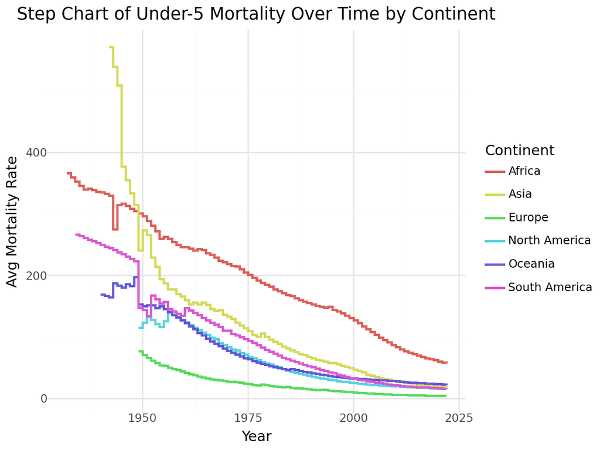

```python
from plotnine import geom_step

step_continent = (
    ggplot(df_continent_trend_pd, aes(x="time_period", y="avg_mortality", color="continent")) +
    geom_step(size=1) +
    labs(
        title="Step Chart of Under-5 Mortality Over Time by Continent",
        x="Year",
        y="Avg Mortality Rate",
        color="Continent"
    ) +
    theme_minimal()
)
step_continent
```